# NMF

Pratheepa Jeganathan

6/19/2019

We have 10 negative control samples and serial dilution of ZymoBIOMICS® Microbial Community Standard.

Looking at the DADA2 pipeline ASVs 2, 3, 4, 5, 6, 7, 8, 11, 17, 37, 22 are in the ZymoBIOMICS® Microbial Community Standard.

Loading packages

```r
library(phyloseq)
library(ggplot2)
library(magrittr)
library(dplyr)
library(reshape2)
# library(rstan)
library(RColorBrewer)
library(wesanderson)
#devtools::install_github("jakobbossek/ggheatmap")
library(ggheatmap)
library(DESeq2)
library(NMF)
```

## Read phyloseq and exploratory analysis

```r
ps = readRDS("./Data/ps_zymo.rds")
if(dim(otu_table(ps))[1]!=ntaxa(ps)){
  otu_table(ps) = t(otu_table(ps))
  }
```

change order of sample names

```r
ncont = paste0("NegativeControl.", seq(1, 10))
stan = paste0("Standard.Dilution.1.",c(1, 6, 36, 216, 1296, 7776, 46656, 279936))

sample_data(ps)$Name = factor(sample_data(ps)$Name, levels = c(ncont,stan))

sample_names(ps) = as.character(sample_data(ps)$Name)
```

Store sequence variants, ASVs, ASV.genus, ASV.genus.species

```r
ASV = as.character(paste0("ASV_", seq(1,ntaxa(ps))))

ASV.Genus = paste0("ASV_", seq(1,ntaxa(ps)), "_", as.character(tax_table(ps)[,6]))

ASV.Genus.Species = paste0(ASV, "_", as.character(tax_table(ps)[,6]), "_", as.character(tax_table(ps)[,7]))

df.ASV = data.frame(seq.variant = taxa_names(ps), ASV = ASV, ASV.Genus = ASV.Genus, ASV.Genus.Species = ASV.Genus.Species)
```

```r
taxa_names(ps) = df.ASV$ASV.Genus
```

## Microbial composition of the ZymoBIOMICS® microbial community standard (Zymo Research, Irvine, CA) measured

True ASVs at genus level

```r
# true.com.ASV = taxa_names(ps)[which(tax_table(ps)[,6] %in% c("Bacillus","Listeria","Staphylococcus", "Lactobacillus", "Escherichia/Shigella", "Enterococcus", "Salmonella", "Pseudomonas"))]
true.com.ASV = taxa_names(ps)[c(2:8,11,17,37,22)]
ps.true = transform_sample_counts(ps, function(OTU) OTU/sum(OTU))
ps.true = prune_taxa(true.com.ASV, ps.true)
ps.true
```

```
## phyloseq-class experiment-level object
## otu_table()   OTU Table:         [ 11 taxa and 18 samples ]
## sample_data() Sample Data:       [ 18 samples by 4 sample variables ]
## tax_table()   Taxonomy Table:    [ 11 taxa by 7 taxonomic ranks ]
```

### Create a list of true ASVs in each diluted sample

```r
true.com.ASV = taxa_names(ps)[c(2:8,11,17,22,37)]
# true.com.ASV = taxa_names(ps)[which((tax_table(ps)[,6] %in% c("Bacillus","Listeria","Staphylococcus", "Lactobacillus", "Escherichia/Shigella", "Enterococcus", "Salmonella", "Pseudomonas")))]

# true.com.ASV = taxa_names(ps)[which((tax_table(ps)[,6] %in% c("Bacillus","Listeria","Staphylococcus", "Lactobacillus", "Escherichia/Shigella", "Enterococcus", "Salmonella", "Pseudomonas"))&(!is.na(tax_table(ps)[,7])))]

diluted.sample.names = sample_names(ps)[3:10]

trueSeq = function(sample.name, true.com.ASV){
  df.sample.i = data.frame(ot = otu_table(ps)[, sample.name])
  names(df.sample.i) = "ot"
  df.sample.i = mutate(df.sample.i, ASV = rownames(df.sample.i))
  df.sample.i.true.seq = filter(df.sample.i, (ot > 0) & (as.character(ASV) %in% true.com.ASV))
  true.seq.sample.i = as.character(df.sample.i.true.seq$ASV)
  return(true.seq.sample.i)
}


true.seq.all.samples = lapply(diluted.sample.names, FUN = trueSeq, true.com.ASV = true.com.ASV)

##true.seq.all.samples
```

### Number of true ASVs in each dilution series sample

```r
number.of.true.ASVs = lapply(true.seq.all.samples,
  function(x) {length(x)})
number.of.true.ASVs
```

```
## [[1]]
## [1] 10
##
## [[2]]
## [1] 11
##
## [[3]]
## [1] 8
##
## [[4]]
## [1] 11
##
## [[5]]
## [1] 11
##
## [[6]]
## [1] 10
##
## [[7]]
## [1] 8
##
## [[8]]
## [1] 8
```

### Number of unique true ASV in all samples

```r
number.of.unique.ASVs.in.all.samples = length(unique(unlist(true.seq.all.samples)))
number.of.unique.ASVs.in.all.samples
```

```
## [1] 11
```

### Check the percentage of eleven ASVs in each dilution series sample

```r
ps.prop = transform_sample_counts(ps, function(otu) otu/sum(otu)*100)
ps.true = prune_taxa(unique(unlist(true.seq.all.samples)), ps)
ps.prop.true = prune_taxa(taxa_names(ps.true), ps.prop)
dt = otu_table(subset_samples(ps.prop.true,
  SampleType == "Standard")) %>% data.frame()
colnames(dt) = sample_data(subset_samples(ps.prop.true,
  SampleType == "Standard"))$Name
#rownames(dt) = df.ASV$ASV.Genus[which(as.character(df.ASV$ASV.Genus.Species) %in% rownames(dt))]
#rownames(dt) = df.ASV$ASV.Genus.Species[which(as.character(df.ASV$ASV.Genus.Species) %in% rownames(dt))]
rownames(dt) = df.ASV$ASV.Genus[which(as.character(df.ASV$ASV.Genus) %in% rownames(dt))]
dt = round(dt, digits = 0)
library(knitr)
kable(dt)
```

|  | Standard.Dilution.1.1 | Standard.Dilution.1.6 | Standard.Dilution.1.36 | Standard.Dilution.1.216 | Standard.Dilution.1.1296 | Standard.Dilution.1.7776 | Standard.Dilution.1.46656 | Standard.Dilution.1.279936 |
| --- | --- | --- | --- | --- | --- | --- | --- | --- |
| ASV_2_Bacillus | 18 | 19 | 22 | 22 | 21 | 20 | 18 | 19 |
| ASV_3_Listeria | 11 | 13 | 14 | 13 | 13 | 14 | 11 | 8 |
| ASV_4_Staphylococcus | 10 | 12 | 14 | 11 | 12 | 13 | 12 | 13 |
| ASV_5_Lactobacillus | 15 | 12 | 13 | 11 | 11 | 12 | 7 | 8 |
| ASV_6_Escherichia/Shigella | 11 | 11 | 12 | 10 | 9 | 10 | 10 | 10 |
| ASV_7_Enterococcus | 9 | 10 | 11 | 11 | 10 | 9 | 16 | 12 |
| ASV_8_Salmonella | 11 | 10 | 9 | 10 | 10 | 9 | 13 | 1 |
| ASV_11_Pseudomonas | 7 | 5 | 4 | 4 | 4 | 5 | 4 | 5 |
| ASV_17_Staphylococcus | 2 | 2 | 0 | 2 | 3 | 2 | 0 | 0 |
| ASV_22_Bacillus | 0 | 2 | 0 | 3 | 3 | 2 | 0 | 0 |
| ASV_37_Escherichia/Shigella | 2 | 2 | 0 | 2 | 1 | 0 | 0 | 0 |

### Adding blocks

We have only one block of samples.

```r
blocks = rep("Set1", nsamples(ps))

sample_data(ps)$block = blocks
```

Identify the species that are not present in at least one `SampleType == Standard` sample and removed them from the phyloseq object. Label these species as contaminants.

```r
ps = prune_taxa(taxa_sums(ps) > 0, ps)
ps.standard = subset_samples(ps, SampleType %in% c("Standard"))
prevTaxaP = apply(otu_table(ps.standard), 1, function(x){sum(x>0)})

Contaminants1 = names(prevTaxaP)[prevTaxaP == 0]
length(Contaminants1)
```

```
## [1] 142
```

```r
ps = prune_taxa(prevTaxaP > 0, ps)
ps
```

```
## phyloseq-class experiment-level object
## otu_table()   OTU Table:         [ 53 taxa and 18 samples ]
## sample_data() Sample Data:       [ 18 samples by 5 sample variables ]
## tax_table()   Taxonomy Table:    [ 53 taxa by 7 taxonomic ranks ]
```

We identified 142 ASVs not is any dilution series samples and they are classified as contaminants before using LDA.

See a summary of the `Standard` and `Negative` samples in each block.

```r
table(sample_data(ps)$SampleType, sample_data(ps)$block)
```

```
##
##            Set1
##   Negative   10
##   Standard    8
```

```r
colSums(otu_table(ps))
```

```
##          NegativeControl.1         NegativeControl.10
##                       3268                      11161
##      Standard.Dilution.1.1      Standard.Dilution.1.6
##                      12404                      21843
##     Standard.Dilution.1.36    Standard.Dilution.1.216
##                      14658                      20601
##   Standard.Dilution.1.1296   Standard.Dilution.1.7776
##                      18127                      17779
##  Standard.Dilution.1.46656 Standard.Dilution.1.279936
##                       5184                       8559
##          NegativeControl.2          NegativeControl.3
##                       8311                       6175
##          NegativeControl.4          NegativeControl.5
##                       7237                      12960
##          NegativeControl.6          NegativeControl.7
##                       4905                      11495
##          NegativeControl.8          NegativeControl.9
##                      10482                      13176
```

## Prepare the phyloseq object for the Bayesian inference

Thus, split the phyloseq object into multiple phyloseq objects corresponding to each block, and store the phyloseq objects as a list of phyloseq objects, `psByBlock`.

Select negative control samples from each block and store as a list of phyloseq objects, `psNCbyBlock`.

Select all species that have a prevalence of zero (i.e., have zero reads) in all negative control samples for each block and store as a list of phyloseq objects, `psallzeroInNC`.

Select all plasma samples from each block and store as a list of phyloseq objects, `psPlByBlock`.

```r
source("psBlockResults.R")
psBlockResult = psBlockResults(ps,
  sampleTypeVar = "SampleType", caselevels = c("Standard"), controllevel="Negative", sampleName = "Name", blockVar = "block")

psByBlock = psBlockResult[[1]]
psNCbyBlock = psBlockResult[[2]]
psallzeroInNC = psBlockResult[[3]]
psPlByBlock = psBlockResult[[4]]
```

## median-of-ratios for each block

```r
lambda.blks = lapply(as.list(seq(1,1)), function(i){
    x = psByBlock[[i]]
    if (dim(otu_table(x))[2] != nsamples(x)) {
            otu_table(x) = t(otu_table(x))
        }
    ot = otu_table(x) %>% data.frame %>% as.matrix

    geo_mean = function(x) {
            if(all(x == 0)){
                val = 0
            }else{
                val = exp(sum(log(x[x > 0]))/length(x))
            }
            return(val)
    }

    geom_mean_row = apply(ot, 1, FUN = geo_mean)

    sj = estimateSizeFactorsForMatrix(ot, median, geoMeans = geom_mean_row)

    ot_col_sum = colSums(ot)
    ot_col_sum_new  = as.matrix(ot_col_sum) * as.matrix(sj)
    lambda = as.numeric(round(ot_col_sum_new, digits = 0)[,1])
    return(lambda)
})
```

## NMF

$A = WH$, where $A$ is the observed count matrix: variables on the rows and samples on the columns.

$W$ Basis vectors - the topics (clusters) discovered from the document.

$H$ Coefficient matrix - the membership weights for the topics in each sample.

```r
x = otu_table(psByBlock[[1]]) %>% data.frame %>% as.matrix
K = 4
res = nmf(x, rank = K, method = "lee")
```

# ASV proportion in each topic discoverd from the samples

```r
W = basis(res)
df = as.data.frame(W)
head(df)
```

```
##                                      V1           V2           V3
## ASV_1_Ralstonia            4.600954e-05 6.294381e-01 4.847072e-05
## ASV_2_Bacillus             1.937214e-01 2.099854e-16 2.220452e-01
## ASV_3_Listeria             1.342976e-01 4.161848e-16 1.272131e-01
## ASV_4_Staphylococcus       1.042575e-01 2.359929e-16 1.452239e-01
## ASV_5_Lactobacillus        1.099823e-01 4.489410e-16 1.229806e-01
## ASV_6_Escherichia/Shigella 9.198661e-02 4.290497e-16 1.202201e-01
##                                      V4
## ASV_1_Ralstonia            1.349015e-12
## ASV_2_Bacillus             7.068914e-03
## ASV_3_Listeria             2.762638e-16
## ASV_4_Staphylococcus       1.600674e-02
## ASV_5_Lactobacillus        2.961736e-16
## ASV_6_Escherichia/Shigella 2.108794e-03
```

```r
df$total = rowSums(df)
df$ASV  = rownames(df)
df = df[order(-df$total), ]
head(df,20)
```

```
##                                                             V1
## ASV_1_Ralstonia                                   4.600954e-05
## ASV_2_Bacillus                                    1.937214e-01
## ASV_4_Staphylococcus                              1.042575e-01
## ASV_3_Listeria                                    1.342976e-01
## ASV_5_Lactobacillus                               1.099823e-01
## ASV_10_Rubrobacter                                6.988135e-16
## ASV_6_Escherichia/Shigella                        9.198661e-02
## ASV_12_Cutibacterium                              4.452820e-09
## ASV_7_Enterococcus                                1.024813e-01
## ASV_8_Salmonella                                  1.061404e-01
## ASV_13_Burkholderia-Caballeronia-Paraburkholderia 9.733168e-16
## ASV_15_Hydrogenophilus                            1.298433e-15
## ASV_18_Anoxybacillus                              1.623331e-15
## ASV_11_Pseudomonas                                4.666437e-02
## ASV_14_Micrococcus                                2.522848e-10
## ASV_16_Pelomonas                                  2.332205e-15
## ASV_17_Staphylococcus                             3.262038e-02
## ASV_34_Pyrinomonas                                2.683274e-15
## ASV_36_Methylocella                               4.390059e-15
## ASV_33_Acidovorax                                 4.163959e-15
##                                                             V2
## ASV_1_Ralstonia                                   6.294381e-01
## ASV_2_Bacillus                                    2.099854e-16
## ASV_4_Staphylococcus                              2.359929e-16
## ASV_3_Listeria                                    4.161848e-16
## ASV_5_Lactobacillus                               4.489410e-16
## ASV_10_Rubrobacter                                6.772068e-03
## ASV_6_Escherichia/Shigella                        4.290497e-16
## ASV_12_Cutibacterium                              9.552087e-03
## ASV_7_Enterococcus                                5.157626e-16
## ASV_8_Salmonella                                  9.436418e-16
## ASV_13_Burkholderia-Caballeronia-Paraburkholderia 1.356050e-02
## ASV_15_Hydrogenophilus                            7.365060e-03
## ASV_18_Anoxybacillus                              1.820279e-02
## ASV_11_Pseudomonas                                3.680089e-14
## ASV_14_Micrococcus                                7.828899e-02
## ASV_16_Pelomonas                                  4.384698e-02
## ASV_17_Staphylococcus                             4.857599e-16
## ASV_34_Pyrinomonas                                4.430320e-06
```

[output cut: 50 more lines]

```
## ASV_10_Rubrobacter                                                               ASV_10_Rubrobacter
## ASV_6_Escherichia/Shigella                                               ASV_6_Escherichia/Shigella
## ASV_12_Cutibacterium                                                           ASV_12_Cutibacterium
## ASV_7_Enterococcus                                                               ASV_7_Enterococcus
## ASV_8_Salmonella                                                                   ASV_8_Salmonella
## ASV_13_Burkholderia-Caballeronia-Paraburkholderia ASV_13_Burkholderia-Caballeronia-Paraburkholderia
## ASV_15_Hydrogenophilus                                                       ASV_15_Hydrogenophilus
## ASV_18_Anoxybacillus                                                           ASV_18_Anoxybacillus
## ASV_11_Pseudomonas                                                               ASV_11_Pseudomonas
## ASV_14_Micrococcus                                                               ASV_14_Micrococcus
## ASV_16_Pelomonas                                                                   ASV_16_Pelomonas
## ASV_17_Staphylococcus                                                         ASV_17_Staphylococcus
## ASV_34_Pyrinomonas                                                               ASV_34_Pyrinomonas
## ASV_36_Methylocella                                                             ASV_36_Methylocella
## ASV_33_Acidovorax                                                                 ASV_33_Acidovorax
```

```r
ASVMatrix = as.data.frame(W)
ASVMatrix$ASV = rownames(ASVMatrix)
colnames(ASVMatrix)[1:K] = paste0("Topic_", seq(1,K))
```

```r
col.topic = c(wes_palette("Cavalcanti1", n = 5), wes_palette("Darjeeling1", n = 5))

plot.all = lapply(as.list(seq(1,K)), function(i){
  newdata = ASVMatrix[order(-ASVMatrix[, i]), ]
  d = newdata
  df = as.data.frame(cbind(d[1:10,]$ASV, as.numeric(d[1:10,][,i])))
  colnames(df) =  c("ASV", "Frequency")
  df$Frequency = as.numeric(df$Frequency)
  df$Frequency = round(df$Frequency, digits = 1)

  df$ASV = factor(df$ASV, levels = df$ASV[order(df$Frequency)])
  p = ggplot(df, aes(x = ASV, y = Frequency)) +
    geom_bar(stat = "identity", fill = col.topic[i], color = "grey50")+
    coord_flip()+
    ggtitle(paste0("Topic " , i)) + theme(axis.text = element_text(size = 14))
  return(p)
})
```

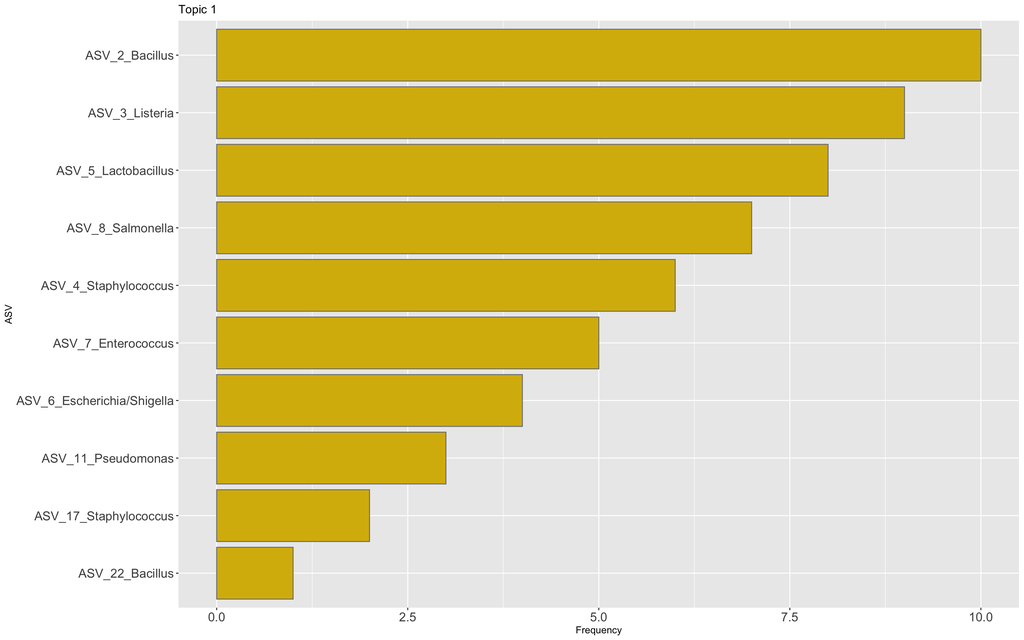

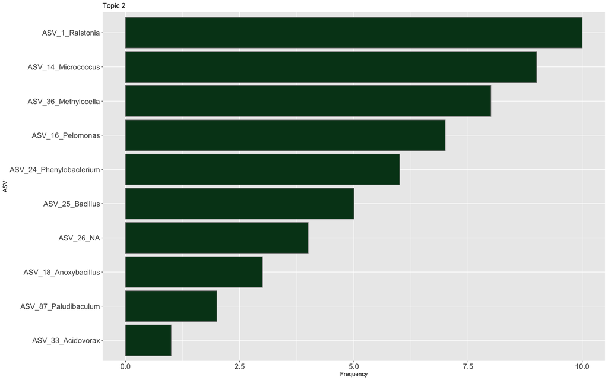

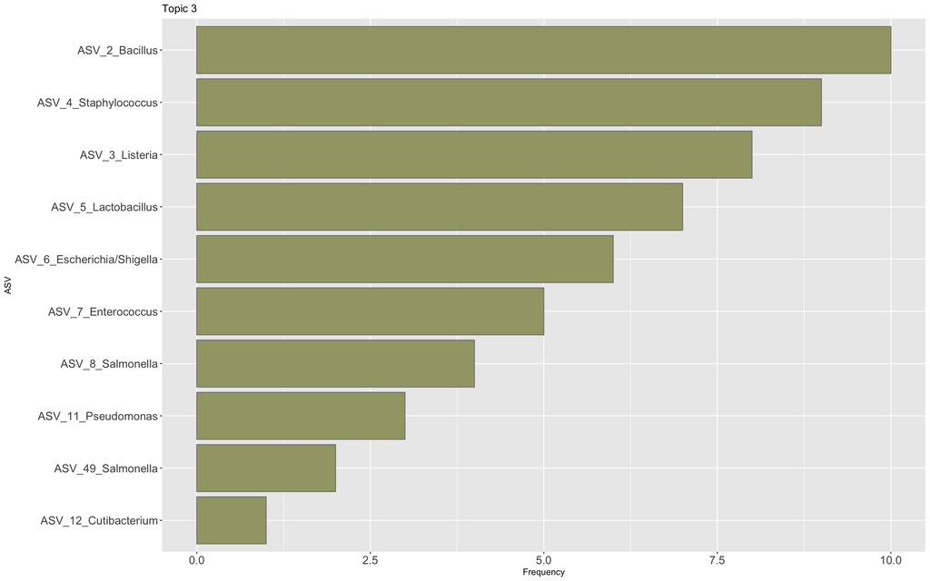

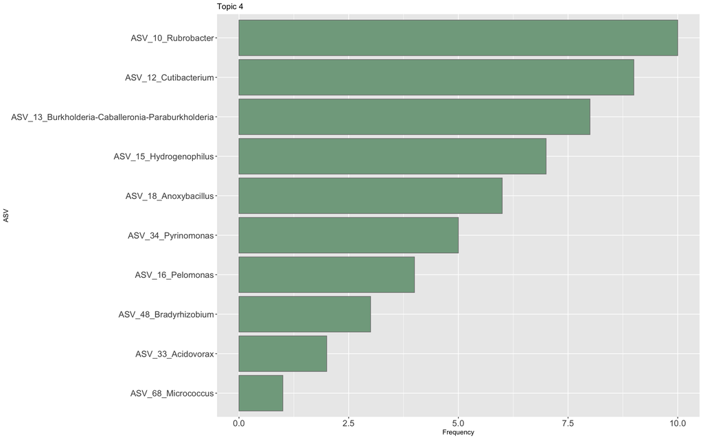

```r
plot.all
```